# Assignment 3: Kickstarter Projects

Richa Gupta

2020-04-08

# Text Mining Kickstarter Projects

## Overview

Kickstarter is an American public-benefit corporation based in Brooklyn, New York, that maintains a global crowd funding platform focused on creativity. The company’s stated mission is to “help bring creative projects to life”.

[figure not shown]

Kickstarter has reportedly received almost $5 billion in pledges from 17.6 million backers to fund 180,000 creative projects, such as films, music, stage shows, comics, journalism, video games, technology and food-related projects.

## Data

The dataset for this assignment is taken from [webroboto.io ‘s repository](https://webrobots.io/kickstarter-datasets/). They developed a scrapper robot that crawls all Kickstarter projects monthly since 2009. We will just take data from the most recent crawl on 2020-02-13.

## Let’s Begin…

### Reading data

```r
setwd(getwd())

data <-
  read.csv('kickstarter_projects_2020_02.csv', stringsAsFactors = FALSE)

data %>%
  head(n = 3) %>%
  gt()
```

| backers_count | blurb | converted_pledged_amount | country | country_displayable_name | created_at | currency | deadline | goal | id | is_starrable | launched_at | name | pledged | slug | source_url | spotlight | staff_pick | state | state_changed_at | location_town | location_state | top_category | sub_category |
| --- | --- | --- | --- | --- | --- | --- | --- | --- | --- | --- | --- | --- | --- | --- | --- | --- | --- | --- | --- | --- | --- | --- | --- |
| 36 | Born out of a mother's desire to provide a safe, nontoxic and natural way for her child to explore and experience art. | 1553 | USA | the United States | 2014-10-08 | USD | 2014-11-14 | 15000 | 1464551434 | FALSE | 2014-10-22 | Le Petit Matisse - Imagine . Create . Share | 1553.0 | le-petit-matisse-imagine-create-share | https://www.kickstarter.com/discover/categories/art/mixed%20media | FALSE | FALSE | failed | 2014-11-14 | Alameda | CA | art | mixed media |
| 1 | This is a photo book project of a minimum of 160 pages. Documenting abandoned businesses in the 159 counties of Georgia. | 10 | USA | the United States | 2015-09-08 | USD | 2015-10-08 | 1500 | 363171617 | FALSE | 2015-09-08 | Forgotten Pieces of Georgia (Canceled) | 10.0 | forgotten-pieces-of-georgia | https://www.kickstarter.com/discover/categories/photography/photobooks | FALSE | FALSE | canceled | 2015-10-01 | East Atlanta | GA | photography | photobooks |
| 859 | Let's enable movement while upholding cultural beliefs, because all girls deserve to play. #UnitedWePlay | 38159 | USA | the United States | 2016-08-08 | USD | 2016-11-17 | 25000 | 1961419297 | FALSE | 2016-10-18 | ASIYA™: Activewear Designed to Enable Muslim Athletes | 38159.2 | asiyatm-activewear-designed-to-enable-muslim-athle | https://www.kickstarter.com/discover/categories/fashion/apparel | TRUE | TRUE | successful | 2016-11-17 | Minneapolis | MN | fashion | apparel |

## Tasks for the Assignment

### 1. Identifying Successful Projects

#### a) Success by Category

There are several ways to identify success of a project:  
- State (`state`): Whether a campaign was successful or not.  
- Pledged Amount (`pledged`)  
- Achievement Ratio: Create a variable `achievement_ratio` by calculating the percentage of the original monetary `goal` reached by the actual amount `pledged` (that is `pledged`\`goal` *100).  
- Number of backers (`backers_count`)  
- How quickly the goal was reached (difference between `launched_at` and `state_changed_at`) for those campaigns that were successful.

Use one or more of these measures to visually summarize which categories were most successful in attracting funding on kickstarter. Briefly summarize your findings.

#### New columns

```r
# What %of money was raised as a factor of goal set
data$achievement_ratio <- (data$pledged / data$goal) * 100

# How quickly the goal was reached
data$weeks_to_goal <-
  as.duration(ymd(data$state_changed_at) - ymd(data$launched_at)) / dweeks(1)

# There is one entry for 1969 this doesn't look right given that kickstarter was itself founded in 2009.
# Removing this one entry from the data
data <- data %>%
  filter(launched_at != "1969-12-31")
```

### Visualising successful projects

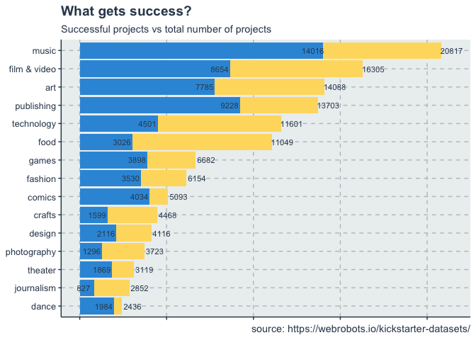

```r
ggplot(NULL, aes(reorder(top_category, n), n)) +

  # All the projects
  geom_bar(
    data = (data %>%
              group_by(top_category) %>%
              summarise(n = n())),
    stat = "identity",
    fill = "#FFDB6D"
  ) +
  geom_text(
    data = (data %>%
              group_by(top_category) %>%
              summarise(n = n())),
    aes(label = n, x = top_category, y = n + 600),
    size = 3
  ) +

  # Successful projects
  geom_bar(data = (
    data %>%
      filter(state == "successful") %>%
      group_by(top_category) %>%
      summarise(n = n())
  ),
  stat = "identity") +
  geom_text(
    data = (
      data %>%
        filter(state == "successful") %>%
        group_by(top_category) %>%
        summarise(n = n())
    ),
    aes(label = n, x = top_category, y = n - 600),
    size = 3
  ) +

  labs(title = "What gets success?",
       subtitle = "Successful projects vs total number of projects",
       caption = "source: https://webrobots.io/kickstarter-datasets/") +
  coord_flip() +
  xlab(NULL) + ylab(NULL) +
  theme(axis.text.x = element_blank())
```

Music has the highest number of successful and total projects. Whereas, Journalism has the lowest number of successful projects.

Despite having less number of projects than art, publishing has more number of successful projects.

Similarly games projects fare better than food projects. Who could have seen that!

Dance has the least number of projects overall but its success is higher than journalism, theater, photography, crafts even.

Dance away Kickstarters!

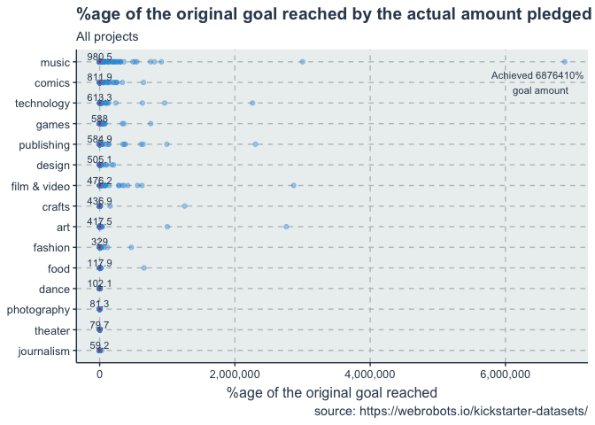

```r
ggplot(data = data, aes(reorder(top_category, achievement_ratio), achievement_ratio)) +
  geom_point(alpha = 0.4) +
  # Adding means
  stat_summary(
    fun.y = mean,
    geom = "point",
    shape = 23,
    size = 1,
    fill = "red"
  ) +
  # Adding text to means
  geom_text(
    data = data %>%
      group_by(top_category) %>%
      summarise(mean = round(mean(achievement_ratio), digits = 1)),
    aes(reorder(top_category, mean), mean, label = mean),
    size = 3,
    vjust = -0.3
  ) +

  # Adding annotation for the outlier
  ggplot2::annotate("text", x = 14, y = 6500000, label = "Achieved 6876410% \n goal amount", size = 3) +
  scale_y_continuous(labels = comma) +
  coord_flip() +
  labs(title = "%age of the original goal reached by the actual amount pledged",
       subtitle = "All projects",
       caption = "source: https://webrobots.io/kickstarter-datasets/", parse = TRUE) +
  xlab(NULL) + ylab("%age of the original goal reached")
```

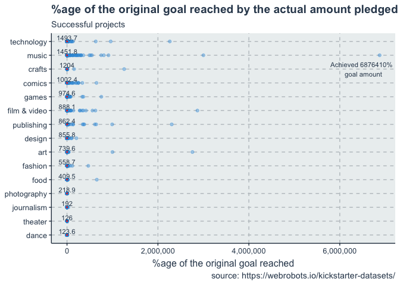

```r
ggplot(data = filter(data, state == "successful"),
       aes(reorder(top_category, achievement_ratio), achievement_ratio)) +
  geom_point(trim = FALSE, alpha = 0.4) +

  # Adding means
  stat_summary(
    fun.y = mean,
    geom = "point",
    shape = 23,
    size = 1,
    fill = "red"
  ) +

  # Adding text to means
  geom_text(
    data = data %>%
      filter(state == "successful") %>%
      group_by(top_category) %>%
      summarise(mean = round(mean(achievement_ratio), digits = 1)),
    aes(reorder(top_category, mean), mean, label = mean),
    size = 3,
    vjust = -0.3
  ) +

  # Removing scientific notation from labels
  scale_y_continuous(labels = comma) +

  # Adding annotation for the outlier
  ggplot2::annotate("text", x = 13, y = 6500000, label = "Achieved 6876410% \n goal amount", size = 3) +

  coord_flip() +

  labs(title = "%age of the original goal reached by the actual amount pledged",
       subtitle = "Successful projects",
       caption = "source: https://webrobots.io/kickstarter-datasets/") +
  xlab(NULL) + ylab("%age of the original goal reached")
```

This is an interesting finding. Although music projects on an average reach highest percentage of pledged money, when it comes to successful projects technology projects are the winners.

This means that even unsuccessful music projects are able to get a lot of pledges but for some reason or the other don’t succeed. Same for comics projects. Getting only money pledged isn’t making enough comics projects laugh!

Is it about the support system for these genres? Maybe technology has more loyal backers than music??

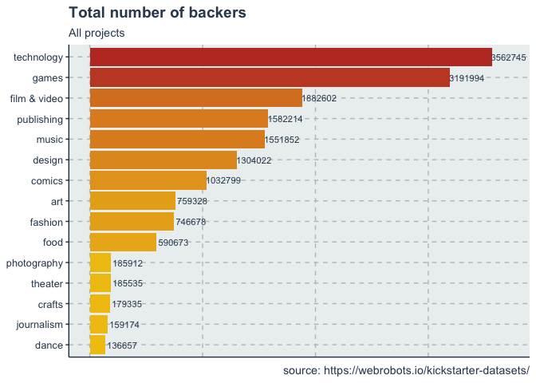

```r
data %>%
  group_by(top_category) %>%
  summarise(total_backers = sum(backers_count)) %>%
  ggplot(aes(
    total_backers,
    reorder(top_category,total_backers),
    fill = total_backers
  )) +

  geom_bar(stat = "identity") +

  geom_text(aes(label = total_backers, x = total_backers + 150000),
                  size = 3) +
  scale_color_gradient() +
  theme(
    legend.position = "none",
    axis.title = element_blank(),
    axis.text.x = element_blank(),
    axis.ticks.x = element_blank()
  ) +
  labs(title = "Total number of backers",
       subtitle = "All projects",
       caption = "source: https://webrobots.io/kickstarter-datasets/")
```

Yup. All technology projects combined have 3.5 million backers (there might be overlaps given 2 projects might have the same backer.), double of music backers!

Seems the kickstarter world is run by people into technology and games! Dungeons and dragons!

However it is heartening to see that despite not having many backers music projects have more successful projects. Maybe liberal arts indeed is a penniless business.

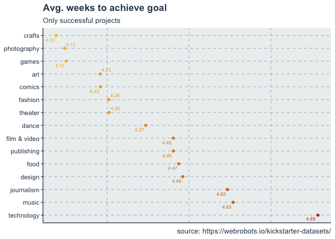

```r
data %>%
  filter(state == "successful") %>%
  group_by(top_category) %>%
  summarise(avg_weeks_to_goal = mean(weeks_to_goal)) %>%
  ggplot(aes(
    avg_weeks_to_goal,
    reorder(top_category,-avg_weeks_to_goal),
    color = avg_weeks_to_goal
  )) +
  geom_point() +
  geom_text_repel(aes(label = round(avg_weeks_to_goal, digits = 2)),
                  size = 2.5) +
  scale_color_gradient() +
  theme(
    legend.position = "none",
    axis.title = element_blank(),
    axis.text.x = element_blank(),
    axis.ticks.x = element_blank()
  ) +
  labs(title = "Avg. weeks to achieve goal",
       subtitle = "Only successful projects",
       caption = "source: https://webrobots.io/kickstarter-datasets/")
```

On average, all the successful projects reach their targets in around 4 weeks.

Successful Crafts projects reach their targets earliest in just 4 weeks or a month. It takes technology projects the most time to reach their targets around 4.89 weeks.

#### **BONUS ONLY:** b) Success by Location

Now, use the location information to calculate the total number of successful projects by state (if you are ambitious, normalize by population). Also, identify the Top 50 “innovative” cities in the U.S. (by whatever measure you find plausible). Provide a leaflet map showing the most innovative states and cities in the U.S. on a single map based on these information.

```r
us.states <- ggplot2::map_data("state")
us.states <- as_data_frame(us.states)
us.states <- dplyr::rename(us.states, state = region)
us.states$state <- str_to_title(us.states$state)
us.states$subregion = NULL
# Add State Abbreviations and Centers
statenames <- as_data_frame(
  cbind(state=state.name, state.abb = state.abb,
        state.center.x = state.center$x,
        state.center.y = state.center$y))
statenames <- statenames %>% mutate_each_(funs(as.numeric),
                 vars=c("state.center.x","state.center.y"))
us.states <- left_join(us.states, statenames, by = "state", by.y = "state")

citynames <- us.cities

# Dropping columns not required in analysis
data_subset <- data[c(1, 13, 19, 21, 22, 23, 25, 26)]

data_subset$location_town_state <- paste(data_subset$location_town, data_subset$location_state, sep = " ")

data_subset_merged <- left_join(data_subset, citynames, by = c("location_town_state" = "name"))

data_subset1 <- data_subset %>%
  filter(state == "successful") %>%
  group_by(location_state) %>%
  summarise(n = n())

data_subset1_merged <- left_join(data_subset1, us.states, by = c("location_state" = "state.abb"))

data_subset1_merged <- data_subset1_merged %>%
  select(n, state) %>%
  unique()

data_subset_merged_top50 <- data_subset_merged %>%
  filter(state == "successful") %>%
  group_by(location_town, lat, long) %>%
  summarise(count = n()) %>%
  arrange(desc(count)) %>% head(50)
```

```r
# Reading in US states data
states <-
  geojson_read(x = "https://raw.githubusercontent.com/PublicaMundi/MappingAPI/master/data/geojson/us-states.json"
               , what = "sp")
# Duplicate
states_all <- states

# Merging the states geo data
combined <- states@data %>%
  left_join(data_subset1_merged, by = c("name" = "state"))
states_all@data <- combined

# states_all <-
#   merge(states, data_subset1_merged, by.x = "name", by.y = "state")

# Creating a variable for project density
states_all@data$projden <- states_all@data$n / states_all@data$density

bins <- c(0, 10, 20, 50, 100, 200, 500, 1000, Inf)
pal <- colorBin("YlOrRd", domain = states$density, bins = bins)
labels <- sprintf("<strong>%s</strong><br/>%g projects",
                  states_all$name,
                  states_all$n) %>% lapply(htmltools::HTML)
labels1 <- sprintf(
  "<strong>%s</strong><br/>%g projects/pop-density",
  states_all$name,
  states_all$projden
) %>% lapply(htmltools::HTML)
labels2 <- sprintf(
  "<strong>%s</strong><br/>%g projects",
  data_subset_merged_top50$location_town,
  data_subset_merged_top50$count
) %>% lapply(htmltools::HTML)
```

```r
m <- leaflet(states_all) %>%
  setView(-96, 37.8, 4) %>%
  addProviderTiles('Stamen.TonerLite', group = "base") %>%
  addPolygons(fillColor = ~pal(n), group = "projects only",
                  weight = 2,
                  opacity = 1,
                  color = "white",
                  dashArray = "3",
                  fillOpacity = 0.7,
                  highlight = highlightOptions(
                    weight = 5,
                    color = "#666",
                    dashArray = "",
                    fillOpacity = 0.7,
                    bringToFront = TRUE),
                  label = labels,
                  labelOptions = labelOptions(
                    style = list("font-weight" = "normal", padding = "3px 8px"),
                    textsize = "15px",
                    direction = "auto")) %>%

  addPolygons(fillColor = ~pal(projden), group = "projects population normalised",
                  weight = 2,
                  opacity = 1,
                  color = "white",
                  dashArray = "3",
                  fillOpacity = 0.7,
                  highlight = highlightOptions(
                    weight = 5,
                    color = "#666",
                    dashArray = "",
                    fillOpacity = 0.7,
                    bringToFront = TRUE),
                  label = labels1,
                  labelOptions = labelOptions(
                    style = list("font-weight" = "normal", padding = "3px 8px"),
                    textsize = "15px",
                    direction = "auto")) %>%

  addCircles(data = data_subset_merged_top50,
                   group = "top 50 cities",
                   label = labels2,
                  labelOptions = labelOptions(
                    style = list("font-weight" = "normal", padding = "3px 8px"),
                    textsize = "15px",
                    direction = "auto")) %>%

  addLayersControl(
    baseGroups = c("base"),
  overlayGroups = c("projects only","projects population normalised", "top 50 cities"),
  options = layersControlOptions(collapsed = TRUE))

m
```

[interactive chart not shown]

### 2. Writing your success story

Each project contains a `blurb` – a short description of the project. While not the full description of the project, the short headline is arguably important for inducing interest in the project (and ultimately popularity and success). Let’s analyze the text.

#### a) Cleaning the Text and Word Cloud

```r
# Subsetting the most successful projects according to the highest achivement ratio
suc <- data %>%
  filter(state == "successful") %>%
  top_n(achievement_ratio, n = 1000) %>%
  select(blurb, backers_count)

# Storing backers_count mean value for use later
suc_backers_count <- mean(suc$backers_count)

# Removing backers_count column from dataframe
suc <- suc %>%
  select(blurb)

# Since there are only 9291 failed projects in total I am also including projects that were canceled as unsuccessful projects.

unsuc <- data %>%
  filter(state == "failed" | state == "canceled") %>%
  head(n = 1000) %>%
  select(blurb, backers_count)

# Storing backers_count mean value for use later
unsuc_backers_count <- mean(unsuc$backers_count)

# Removing backers_count column from dataframe
unsuc <- unsuc %>%
  select(blurb)

# Joining all the 1000 blurbs
suc_blurbs <- paste0(suc$blurb, collapse = " ")
unsuc_blurbs <- paste0(unsuc$blurb, collapse = " ")

doc_id <- c(1:1000)

suc <-
  data.frame(doc_id, text = suc$blurb, stringsAsFactors = FALSE)
unsuc <-
  data.frame(doc_id, text = unsuc$blurb, stringsAsFactors = FALSE)

doc_id <- c(1:2)

# creating a unified dataframe with one column textid, second column blurbs
all <-
  data.frame(doc_id,
             text = c(suc_blurbs, unsuc_blurbs),
             stringsAsFactors = FALSE)
```

```r
# Create a DataframeSource from suc
# data frame source interprets each row of the
# data frame x as a document.
suc_df <- DataframeSource(suc)
unsuc_df <- DataframeSource(unsuc)

all_df <- DataframeSource(all)

# Convert df_suc to a corpus: suc_corpus
## Note: there are two types (VCopus vs PCorpus)
suc_corpus <- VCorpus(suc_df)
unsuc_corpus <- VCorpus(unsuc_df)

all_corpus <- VCorpus(all_df)

# Examine suc_corpus
suc_corpus
```

```
## <<VCorpus>>
## Metadata:  corpus specific: 0, document level (indexed): 0
## Content:  documents: 1000
```

```r
print(paste0("cleaned text: ", suc_clean[[13]][1]))
```

```
## [1] "cleaned text: marc miller crafted vision traveller universe novel showing grand sweep vast empire far future"
```

```r
print(paste0("original blurb: ", suc$text[13]))
```

```
## [1] "original blurb: Marc Miller has crafted his vision of the Traveller universe: a novel showing the grand sweep of the vast empire of the far future."
```

```r
# Stem all words
suc_stemmed <- tm_map(suc_clean, stemDocument)
unsuc_stemmed <- tm_map(unsuc_clean, stemDocument)

# Show one example
print(paste0("Stemmed blurb: ", suc_stemmed[[13]]$content))
```

```
## [1] "Stemmed blurb: marc miller craft vision travel univers novel show grand sweep vast empir far futur"
```

```r
# Create the dtm from the corpus: suc_dtm
suc_dtm <- DocumentTermMatrix(suc_stemmed)
unsuc_dtm <- DocumentTermMatrix(unsuc_stemmed)

# Print out suc_dtm data
suc_dtm
```

```
## <<DocumentTermMatrix (documents: 1000, terms: 3638)>>
## Non-/sparse entries: 10418/3627582
## Sparsity           : 100%
## Maximal term length: 36
## Weighting          : term frequency (tf)
```

Provide a word cloud of the most frequent or important words (your choice which frequency measure you choose) among the most successful projects.

```r
suc_tdm <- TermDocumentMatrix(suc_clean)
unsuc_tdm <- TermDocumentMatrix(unsuc_clean)

all_tdm <- TermDocumentMatrix(all_clean)

suc_m <- as.matrix(suc_tdm)
unsuc_m <- as.matrix(unsuc_tdm)

all_m <- as.matrix(all_tdm)

suc_v <- sort(rowSums(suc_m), decreasing = TRUE)
suc_d <- data.frame(word = names(suc_v), freq = suc_v)

unsuc_v <- sort(rowSums(unsuc_m), decreasing = TRUE)
unsuc_d <- data.frame(word = names(unsuc_v), freq = unsuc_v)

head(suc_d, 10) %>%
  gt()
```

| word | freq |
| --- | --- |
| new | 87 |
| enamel | 65 |
| game | 58 |
| art | 50 |
| pins | 47 |
| first | 45 |
| can | 44 |
| one | 43 |
| get | 42 |
| make | 37 |

```r
# all_m[1700:1705,1:2]
```

#### Word cloud for 100 most common words in blurbs of successful projects.

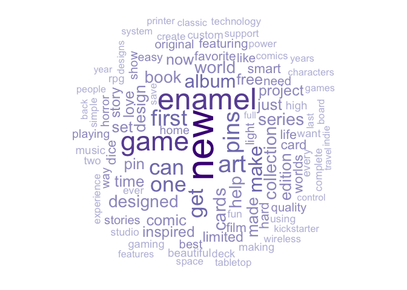

```r
purples <- brewer.pal(7, "Purples")
purples <- purples[-c(1:2)]
set.seed(1234)
wordcloud(
  words = suc_d$word,
  freq = suc_d$freq,
  min.freq = 1,
  max.words = 100,
  random.order = FALSE,
  rot.per = 0.35,
  colors = purples
)
```

Many successful projects mention words like game, new, enamel. There is a lot of information here but doesn’t seem too useful.

#### Word cloud for 100 most common words in blurbs of unsuccessful projects.

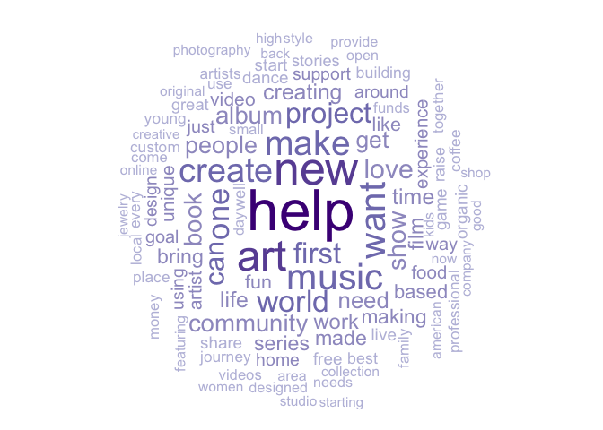

```r
set.seed(1234)
wordcloud(words = unsuc_d$word, freq = unsuc_d$freq, min.freq = 1,
          max.words=100, random.order=FALSE, rot.per=0.35,
          colors=purples)
```

One word that stands out in blurbs of unsuccessful projects is help. I guess people don’t want “help” so much. Some other words that grab attention are community, art, music. Well this reinstates the fact that liberal arts project do fall behind when it comes to being successful.

#### b) Success in words

Provide a pyramid plot to show how the words between successful and unsuccessful projects differ in frequency. A selection of 10 - 20 top words is sufficient here.

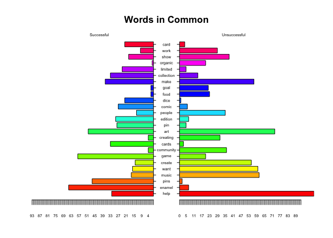

```r
# Create common_words
common_words <- subset(all_m, all_m[, 1] > 0 & all_m[, 2] > 0)

# Create difference
difference <- abs(common_words[, 1] - common_words[, 2])

# Combine common_words and difference
common_words <- cbind(common_words, difference)

# Order the data frame from most differences to least
common_words <- common_words[order(common_words[, 3], decreasing = TRUE), ]

# Create top25_df
top25_df <- data.frame(x = common_words[1:25, 1],
                       y = common_words[1:25, 2],
                       labels = rownames(common_words[1:25, ]))

# Create the pyramid plot
p <- pyramid.plot(top25_df$x, top25_df$y,
                  labels = top25_df$labels,
             gap = 10,
             top.labels = c("Successful", " ", "Unsuccessful"),
             main = "Words in Common",
             laxlab = NULL,
             raxlab = NULL,
             unit = NULL,
             labelcex=0.5)
```

Like we noticed earlier also, the word help is exceedingly featured in unsuccessful project blurbs. There is also more mention of words like organic, goal, food, people, create, want, music in unsuccessful blurbs.

Although before over analysing this we need to be aware that this graph only has 1000 blurbs of each category. So we cannot generalise too much.

#### c) Simplicity as a virtue

These blurbs are short in length (max. 150 characters) but let’s see whether brevity and simplicity still matters. Calculate a readability measure (Flesh Reading Ease, Flesh Kincaid or any other comparable measure) for the texts. Visualize the relationship between the readability measure and one of the measures of success. Briefly comment on your finding.

```r
# Calculating the scores for each blurb and then averaging the values
suc_temp <- quanteda::textstat_readability(suc$text,
        measure=c('Flesch.Kincaid',
                  'meanSentenceLength','meanWordSyllables',
                  'Dale.Chall', 'FOG', 'ARI', 'SMOG'))
unsuc_temp <- quanteda::textstat_readability(unsuc$text,
        measure=c('Flesch.Kincaid',
                  'meanSentenceLength','meanWordSyllables',
                  'Dale.Chall', 'FOG', 'ARI', 'SMOG'))

# Ignoring the column with textids
suc_temp <- data.frame(suc = apply(suc_temp[,2:8], 2, mean))
unsuc_temp <- data.frame(unsuc = apply(unsuc_temp[,2:8], 2, mean))

suc_temp <- t(suc_temp)
unsuc_temp <- t(unsuc_temp)

all_temp <- as.data.frame(rbind(suc_temp, unsuc_temp))

# backers_count as measure of success (stored earlier)
all_temp$backers_count <- c(suc_backers_count, unsuc_backers_count)
```

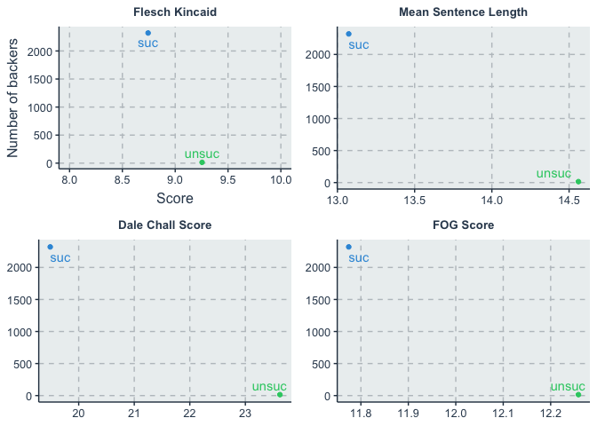

```r
p <- ggplot(all_temp, aes(color = as.factor(rownames(all_temp)))) +
  theme(legend.position = "none",
        plot.title = element_text(size = 10, hjust = 0.5))

p1 <- p + geom_point(aes(x = Flesch.Kincaid, y = backers_count)) +
  geom_text(aes(
    label = rownames(all_temp),
    x = Flesch.Kincaid,
    y = backers_count
  ),
  vjust = c(1.5,-0.5)) +
  labs(title = "Flesch Kincaid") + xlim(8, 10) + ylab("Number of backers") + xlab("Score")

p2 <-
  p + geom_point(aes(x = meanSentenceLength, y = backers_count)) +
  geom_text(
    aes(
      label = rownames(all_temp),
      x = meanSentenceLength,
      y = backers_count
    ),
    vjust = c(1.5,-0.5),
    hjust = c(0, 1.2)
  ) +
  labs(title = "Mean Sentence Length") + ylab(NULL) + xlab(NULL)

p3 <- p + geom_point(aes(x = Dale.Chall, y = backers_count)) +
  geom_text(
    aes(
      label = rownames(all_temp),
      x = Dale.Chall,
      y = backers_count
    ),
    vjust = c(1.5,-0.5),
    hjust = c(0, 0.8)
  ) +
  labs(title = "Dale Chall Score") + ylab(NULL)+ xlab(NULL)

p4 <- p + geom_point(aes(x = FOG, y = backers_count)) +
  geom_text(
    aes(
      label = rownames(all_temp),
      x = FOG,
      y = backers_count
    ),
    vjust = c(1.5,-0.5),
    hjust = c(0, 0.8)
  ) +
  labs(title = "FOG Score") + ylab(NULL) + xlab(NULL)


grid.arrange(p1, p2, p3, p4, ncol = 2)
```

Successful proects seem to have simpler language and have in general lower readability scores than blurbs of unsuccessful projects. Unsuccessful projects might be so because of the use of complex or convoluted language.

### 3. Sentiment

Now, let’s check whether the use of positive / negative words or specific emotions helps a project to be successful.

#### a) Stay positive

Calculate the tone of each text based on the positive and negative words that are being used. You can rely on the Hu & Liu dictionary provided in lecture or use the Bing dictionary contained in the tidytext package (`tidytext::sentiments`). Visualize the relationship between tone of the document and success. Briefly comment.

```r
pos <- read.table("dictionaries/positive-words.txt", as.is = T)
neg <- read.table("dictionaries/negative-words.txt", as.is = T)

sentiment <- function(words = c("really great good stuff bad")) {
  require(quanteda)
  tok <- quanteda::tokens(words)
  pos.count <- sum(tok[[1]] %in% pos[, 1])
  neg.count <- sum(tok[[1]] %in% neg[, 1])
  out <- (pos.count - neg.count) / (pos.count + neg.count)
  return(out)
}
```

```r
suc_copy <- suc
unsuc_copy <- unsuc
suc_copy$senti <- map_dbl(suc_copy$text, sentiment)
unsuc_copy$senti <- map_dbl(unsuc_copy$text, sentiment)

suc_temp <- data.frame(cbind(suc_copy$senti, unsuc_copy$senti))
```

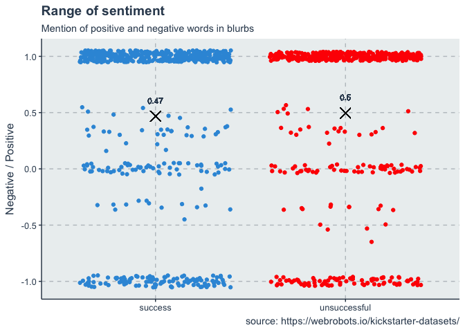

```r
ggplot(suc_temp) +
  geom_jitter(aes(x = "success", y = suc_temp$X1)) +
  geom_jitter(aes(x = "unsuccessful", y = suc_temp$X2), color = "red") +
  geom_point(
    aes(x = "success", y = mean(suc_temp$X1, na.rm = TRUE)),
    color = "black",
    shape = 4,
    size = 5
  ) +
  geom_text(
  aes(x = "success", y = mean(suc_temp$X1, na.rm = TRUE) + 0.1, label = round(mean(suc_temp$X1, na.rm = TRUE), digits = 2)), size = 3, vjust = -0.3) +
  geom_point(
    aes(x = "unsuccessful", y = mean(suc_temp$X2, na.rm = TRUE)),
    color = "black",
    shape = 4,
    size = 5
  ) +
  geom_text(
  aes(x = "unsuccessful", y = mean(suc_temp$X2, na.rm = TRUE) + 0.1, label = round(mean(suc_temp$X2, na.rm = TRUE), digits = 2)), size = 3, vjust = -0.3) +
  scale_color_gradient() +
  labs(title = "Range of sentiment",
       subtitle = "Mention of positive and negative words in blurbs",
       caption = "source: https://webrobots.io/kickstarter-datasets/", parse = TRUE) +
  xlab(NULL) + ylab("Negative / Positive")
```

There doesn’t seem to be much difference when it comes to only positive and negative emotions. Unsuccessful blurbs are ever so slightly more positive than successful blurbs.

#### b) Positive vs negative

Segregate all 2,000 blurbs into positive and negative texts based on their polarity score calculated in step (a). Now, collapse the positive and negative texts into two larger documents. Create a document-term-matrix based on this collapsed set of two documents. Generate a comparison cloud showing the most-frequent positive and negative words.

```r
pos <- rbind((suc_copy %>%
                filter(senti > 0) %>%
                select(text)),
             (unsuc_copy %>%
                filter(senti > 0) %>%
                select(text)))

neg <- rbind((suc_copy %>%
                filter(senti < 0) %>%
                select(text)),
             (unsuc_copy %>%
                filter(senti < 0) %>%
                select(text)))

pos <- paste0(pos$text, collapse = " ")

neg <- paste0(neg$text, collapse = " ")

doc_id <- c("pos", "neg")

# creating a unified dataframe with one column textid, second column blurbs
posneg <-
  data.frame(doc_id,
             text = c(pos, neg),
             stringsAsFactors = FALSE)

posneg_df <- DataframeSource(posneg)

posneg_corpus <- VCorpus(posneg_df)

posneg_clean <- clean_corpus(posneg_corpus)

posneg_tdm <- TermDocumentMatrix(posneg_clean)

posneg_m <- as.matrix(posneg_tdm)
```

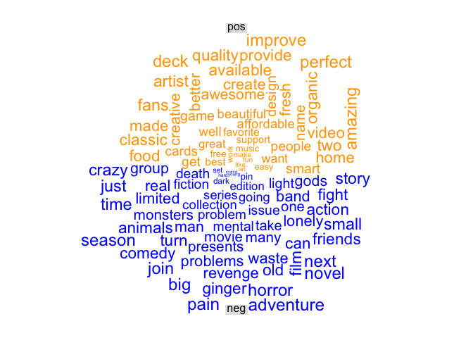

```r
# Create comparison cloud
comparison.cloud(posneg_m, colors = c("orange", "blue"),
                 scale=c(0.1,2), title.size= 1,
                 max.words = 100)
```

A picture is worth 200 words. Here is collection of 100 most-frequent positive and negative words that have been used in the subset of 2000 blurbs.

Some of the positive words are obvious like awesome, beautiful, provide, perfect.

Some words that have been categorized as negative are confusing like - friends, animals, edition, series, ginger.

More analysis needs to be done as to why has the dictionary classified these words as negative.

#### c) Get in their mind

Now, use the NRC Word-Emotion Association Lexicon in the tidytext package to identify a larger set of emotions (anger, anticipation, disgust, fear, joy, sadness, surprise, trust). Again, visualize the relationship between the use of words from these categories and success. What is your finding?

```r
all_m_df <- as.data.frame(all_m)

all_m_df$word = rownames(all_m_df)

all_senti <- inner_join(all_m_df, get_sentiments("nrc"), by = "word")
```

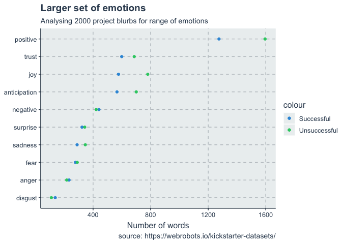

```r
all_senti %>%
  group_by(sentiment) %>%
  summarise(sum_suc_senti = sum(`1`),
            sum_unsuc_senti = sum(`2`)) %>%
  ggplot() +
  geom_point(aes(reorder(sentiment, sum_suc_senti), y = sum_suc_senti, color = "Successful")) +
  geom_point(aes(sentiment, sum_unsuc_senti, color = "Unsuccessful")) +
  labs(title = "Larger set of emotions",
       subtitle = "Analysing 2000 project blurbs for range of emotions",
       caption = "source: https://webrobots.io/kickstarter-datasets/", parse = TRUE) +
  xlab(NULL) + ylab("Number of words") +
  coord_flip()
```

Unsuccessful projects have more positive, trust, joy, anticipation feelings.

And when it comes to negative emotions like- sadness, fear, anger, disgust both blurbs have almost same number of words.

This graph seems to imply that maybe projects that oversell positivity are not liked much by the Kickstarter pledgers.